# QDA-Lab-5-Part-2

Dr Isabel Sassoon

Octorber 2022

# Week 5 Independent practice A solution

## Loading the libraries used in this analysis

```r
library(ggplot2)
```

# In this lab you will use a data set that contains information on 78 people using one of three diets.

The data includes the following variables:

- Person Participant id
- gender Gender, 1 = male, 0 = female
- Age Age in years
- Height Height in cm
- preweight Weight before the diet (kg)
- Diet Diet type
- weight6weeks Weight after 6 weeks (kg)

# (1) Data

Loading the data into R.

```r
diet.df<-read.csv("Diet_r.csv")
```

# (2) Exploring the data

Numerical summaries of all the attributes in the data can be obtained using the summary function.

```r
summary(diet.df)
```

```
##      Person          gender            Age            Height
##  Min.   : 1.00   Min.   :0.0000   Min.   :16.00   Min.   :141.0
##  1st Qu.:20.25   1st Qu.:0.0000   1st Qu.:32.25   1st Qu.:164.2
##  Median :39.50   Median :0.0000   Median :39.00   Median :169.5
##  Mean   :39.50   Mean   :0.4342   Mean   :39.15   Mean   :170.8
##  3rd Qu.:58.75   3rd Qu.:1.0000   3rd Qu.:46.75   3rd Qu.:174.8
##  Max.   :78.00   Max.   :1.0000   Max.   :60.00   Max.   :201.0
##                  NA's   :2
##    pre.weight          Diet        weight6weeks
##  Min.   : 58.00   Min.   :1.000   Min.   : 53.00
##  1st Qu.: 66.00   1st Qu.:1.000   1st Qu.: 61.85
##  Median : 72.00   Median :2.000   Median : 68.95
##  Mean   : 72.53   Mean   :2.038   Mean   : 68.68
##  3rd Qu.: 78.00   3rd Qu.:3.000   3rd Qu.: 73.83
##  Max.   :103.00   Max.   :3.000   Max.   :103.00
##
```

The interpretation for the Age, height and weight variables seems consistent with them being numeric. Notice that the data has not been “interpreted” as intended by the import. For example gender has two values and is binary (in this data set) yet here it was treated as a number.

Also note that there are 2 missing values for gender.

The *as.factor* R function can help fix this, as we want the variable gender to be treated as a category.

```r
diet.df$gender<-as.factor(diet.df$gender)
```

Lets look at the Diet variable:

```r
table(diet.df$Diet)
```

```
##
##  1  2  3
## 24 27 27
```

This also is a categorical variable that has been imported as a number so lets fix this too

```r
diet.df$Diet<-as.factor(diet.df$Diet)
```

Note: it is also possible to create a new variable to contain the factor version of the gender and the diet type.

# Graphical exploration of the data

Initially here are histograms for each variable in turn. This helps us see if there are any strange skews (lack of symmetry) in the data.

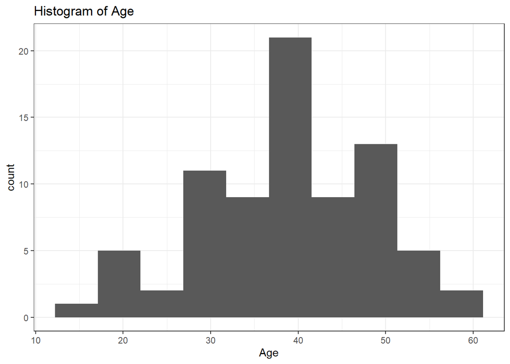

```r
ggplot(diet.df, aes(x=Age)) + geom_histogram(bins=10) + theme_bw() + ggtitle("Histogram of Age")
```

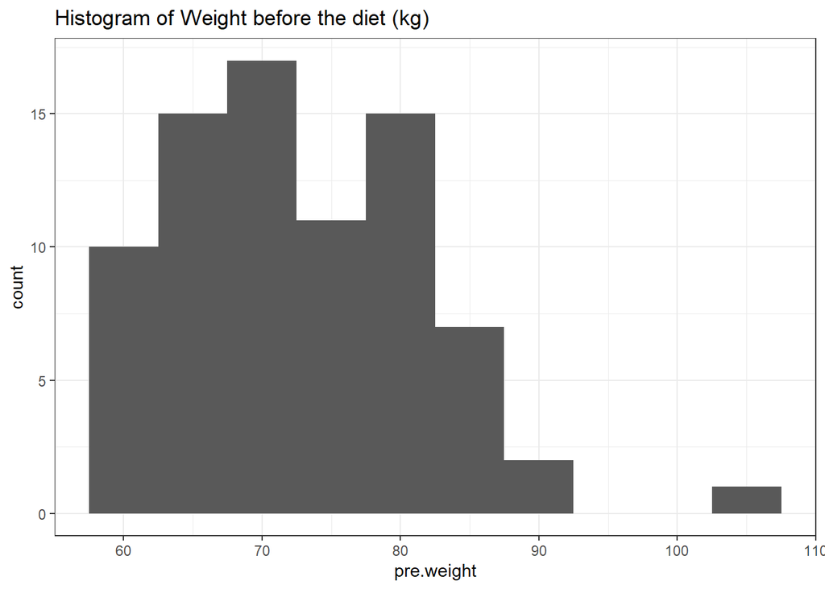

```r
ggplot(diet.df, aes(x=pre.weight)) + geom_histogram(bins=10) + theme_bw() + ggtitle("Histogram of Weight before the diet (kg)")
```

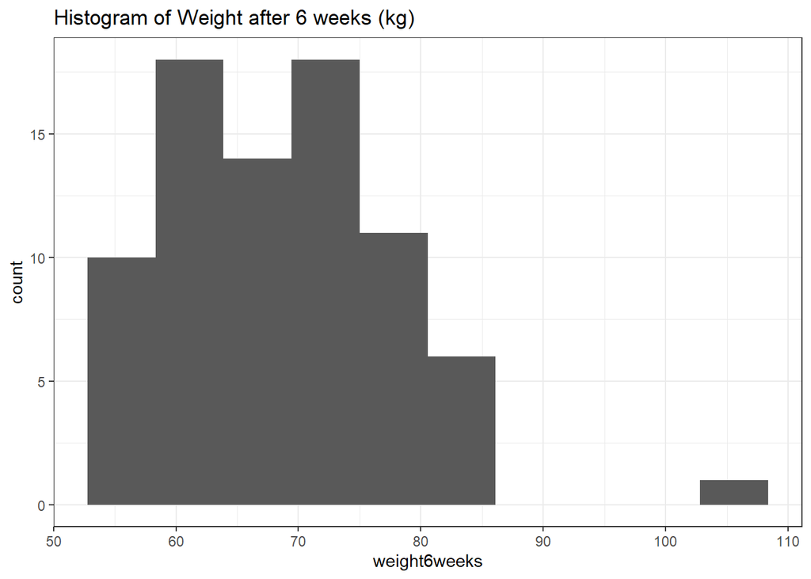

```r
ggplot(diet.df, aes(x=weight6weeks)) + geom_histogram(bins=10) + theme_bw() + ggtitle("Histogram of Weight after 6 weeks (kg)")
```

The histograms do not point to any problems in the data. The values for age and weight all seem plausible. There are some higher values in weight (above 100kg) but these are not implausible. There are no negative values or any missing values.

## Two way plots

We can now explore the relationships between the variables too:

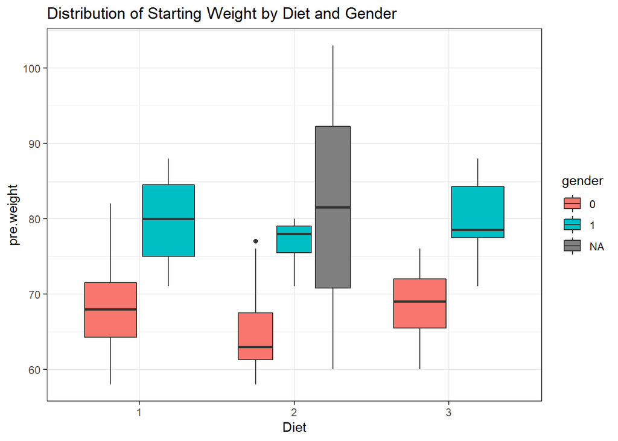

```r
ggplot(diet.df, aes(x=Diet, y=pre.weight, fill=gender)) +geom_boxplot() + theme_bw() +
  ggtitle("Distribution of Starting Weight by Diet and Gender")
```

Interestingly there is some missing data, but only for Gender (we also saw that in the summary function). If we were planning to use Gender in our models we may want to remove the rows with these missing values. We may also scrutinize those rows of data, in case there are any anomalies in the whole row of data.

From the box plot we can see that there seems to be a difference in the gender on the pre-weight medians.

# (3) Hypothsis testing that the mean weight before the diet is the same as after

For this we can use the t-test to test the hypothesis $H_0$ mean weight before the diet is the same as the mean weight after the diet vs the $H_1$ the means are different.

```r
t.test(diet.df$pre.weight, diet.df$weight6weeks)
```

```
##
##  Welch Two Sample t-test
##
## data:  diet.df$pre.weight and diet.df$weight6weeks
## t = 2.721, df = 153.92, p-value = 0.007259
## alternative hypothesis: true difference in means is not equal to 0
## 95 percent confidence interval:
##  1.053396 6.636348
## sample estimates:
## mean of x mean of y
##  72.52564  68.68077
```

The p-value for this t-test is significant (0.007259), as such we have evidence to reject the Null hypothesis in this case. Based on this data there is a significant difference before vs after weights.

# (4) Compute the weight lost

In order to model the effect of diet type on weight lost we need to compute the weight lost using the weight before - the weight after 6 weeks.

$$\text{weight.lost}=\text{pre.weight}
- \text{weight6weeks}$$
We can compute this new variable using:

```r
diet.df$weight.lost<-diet.df$pre.weight-diet.df$weight6weeks
```

Lets see what this new variable looks like:

```r
summary(diet.df$weight.lost)
```

```
##    Min. 1st Qu.  Median    Mean 3rd Qu.    Max.
##  -2.100   2.000   3.600   3.845   5.550   9.200
```

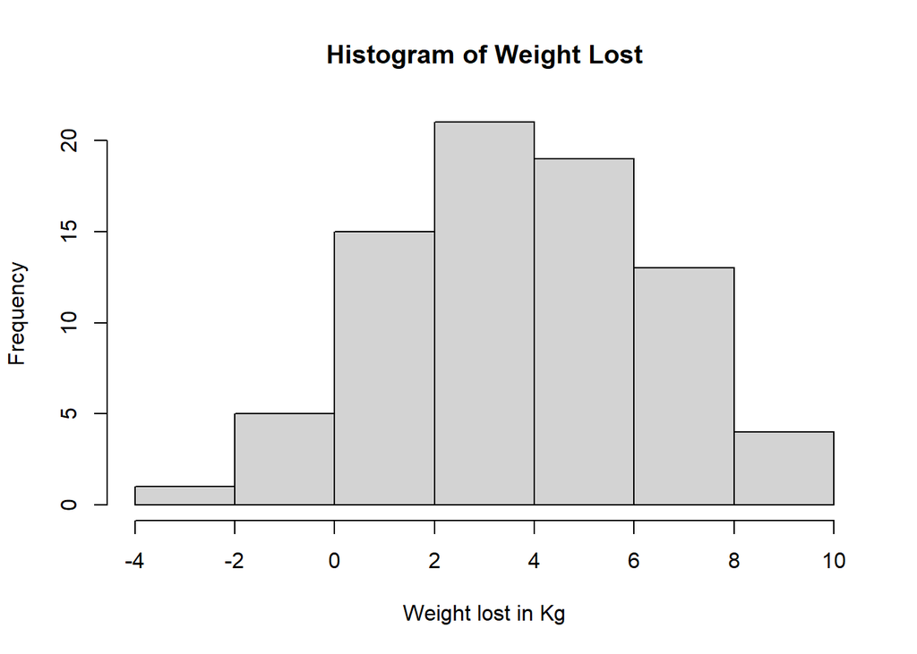

```r
hist(diet.df$weight.lost, main="Histogram of Weight Lost", xlab="Weight lost in Kg")
```

From the histogram is looks like most of the people in the sample have lost weight, as the bulk of the data points are above 0.

But can this weight loss be explained by one specific diet? Was there different mean weight losses for te each of the three diets?

# (5) Model the relationship between the weight lost and the other measurments or demographics provided in the data

Lets start by modeling the weight lost vs the diet used. The weight lost is our dependent variable and is numerical. The Diet used is our explanatory variable and it is categorical.

The first model uses only the diet type to model the weight lost. This is achieved using ANOVA.

```r
summary(aov(diet.df$weight.lost~diet.df$Diet))
```

```
##              Df Sum Sq Mean Sq F value  Pr(>F)
## diet.df$Diet  2   71.1   35.55   6.197 0.00323 **
## Residuals    75  430.2    5.74
## ---
## Signif. codes:  0 '***' 0.001 '**' 0.01 '*' 0.05 '.' 0.1 ' ' 1
```

We can see that the F-value is significant, so there is a difference between the mean weight lost for each of the three diets.

This below is a different output for the same model. It gives us more information:

```r
summary.lm(aov(diet.df$weight.lost~diet.df$Diet))
```

```
##
## Call:
## aov(formula = diet.df$weight.lost ~ diet.df$Diet)
##
## Residuals:
##     Min      1Q  Median      3Q     Max
## -5.1259 -1.3815  0.1759  1.6519  5.7000
##
## Coefficients:
##               Estimate Std. Error t value Pr(>|t|)
## (Intercept)     3.3000     0.4889   6.750 2.72e-09 ***
## diet.df$Diet2  -0.2741     0.6719  -0.408  0.68449
## diet.df$Diet3   1.8481     0.6719   2.751  0.00745 **
## ---
## Signif. codes:  0 '***' 0.001 '**' 0.01 '*' 0.05 '.' 0.1 ' ' 1
##
## Residual standard error: 2.395 on 75 degrees of freedom
## Multiple R-squared:  0.1418, Adjusted R-squared:  0.1189
## F-statistic: 6.197 on 2 and 75 DF,  p-value: 0.003229
```

From this output we can see that although the F was significant our $r^2$ is low. The difference in the diets seem to be between Diets 1,2 and Diet 3.

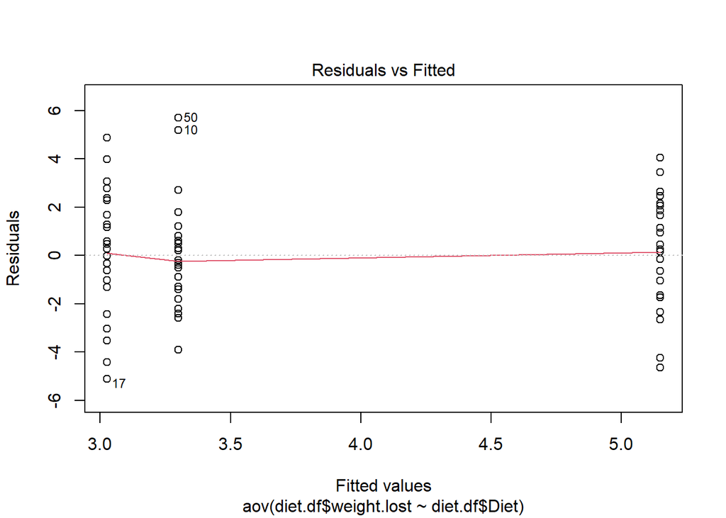

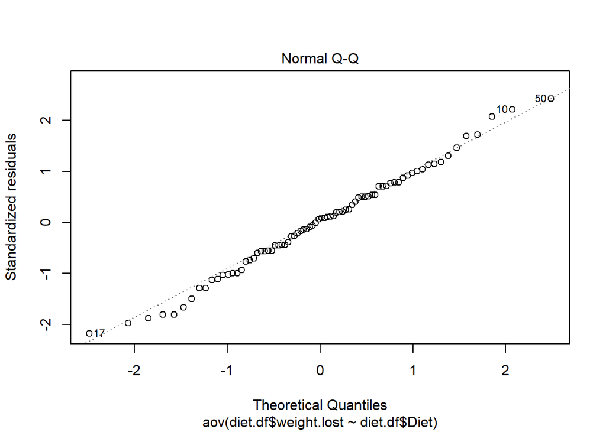

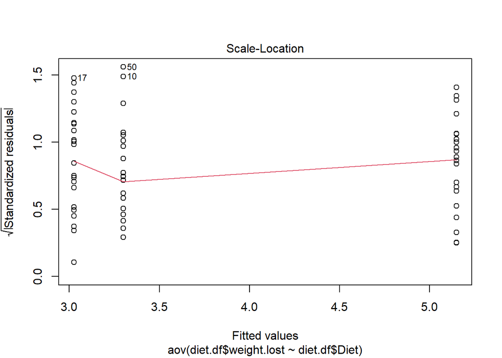

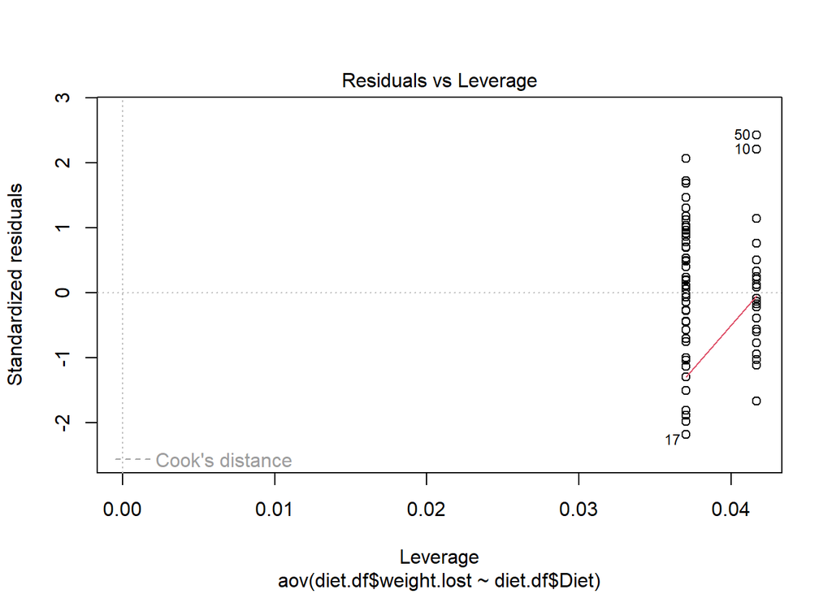

```r
plot(aov(diet.df$weight.lost~diet.df$Diet))
```

The plots for the residuals do not point to any issues. We see constant variance for the residuals plot (plot1) and normally distributed residuals in plot 2.

*Note: the aov function was used here but the lm function could also have been used.*

Going back to the means for the different diets, lets compute them:

```r
aggregate(diet.df$weight.lost~diet.df$Diet, FUN="mean")
```

| diet.df$Diet | diet.df$weight.lost |
| --- | --- |
| 1 | 3.300000 |
| 2 | 3.025926 |
| 3 | 5.148148 |

Seems like diet 3 causes higher weight loss, but the difference between diet 1 and 2 is much smaller - as we saw in the anova model summary.

We can look at this also with a boxplot.

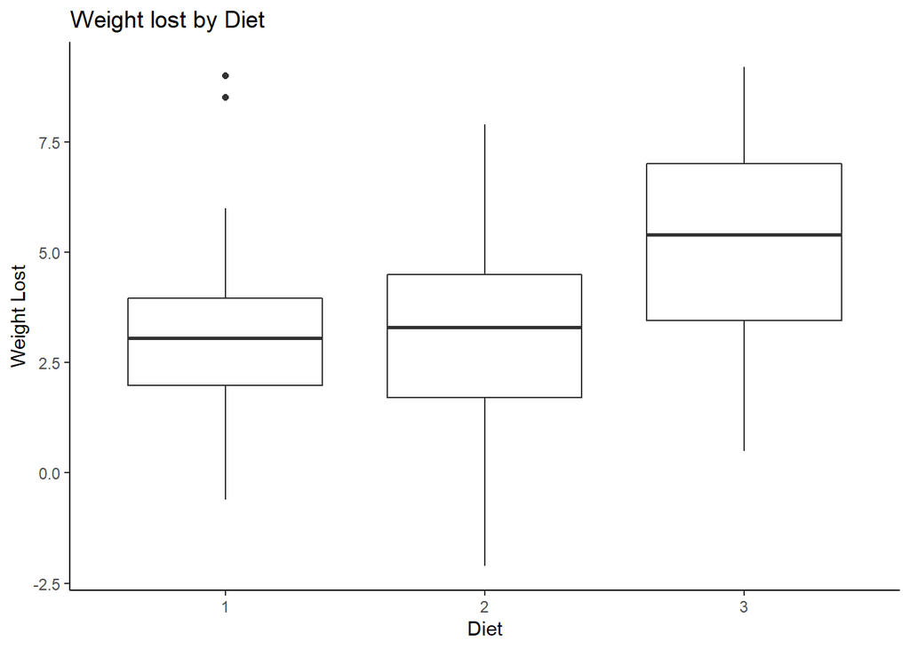

```r
ggplot(diet.df, aes(x=Diet, y=weight.lost)) + geom_boxplot() + theme_classic() + ggtitle("Weight lost by Diet") + ylab("Weight Lost")
```

The box plot confirms that Diet 1 and 2 have a similar result in terms of weight lost. Diet three seems more effective as it has a higher median weight lost.

### What to look for in an ANOVA analysis output?

- In the summary(aov()) check if the F statistic is significant. If it is significant then the means are different for the categorical variable values.
- In the summary.lm(aov()) check the direction and the significance of the estimates for the different levels of the categorical variables. Are they significant? Are they positive or negative? Also pay attention to the default category - which is represented by the intercept.
- In plot(aov()) check the first two plots. In the first plot “residuals vs fitted” we want constant variance - this means a straightish red line and the spread of points that is similar for all the x values. In the second plot “QQplot” we want to see the points (represented by round circles) to be as close to the straignt line as possible. Check if there are some suspicious outliers.

# other attributes may affect the weight loss

We started by modeling the weight lost using the Diet type only (and used ANOVA).

Lets introduce Age, and in this case we want to do this we are going to apply an ANCOVA model because our target variable is numeric, and we have both numeric and categorical explanatory variables. An ANCOVA model uses the same lm function syntax as the linear regression.

```r
model2<-lm(diet.df$weight.lost~diet.df$Diet+diet.df$Age)
summary(model2)
```

```
##
## Call:
## lm(formula = diet.df$weight.lost ~ diet.df$Diet + diet.df$Age)
##
## Residuals:
##    Min     1Q Median     3Q    Max
## -5.096 -1.443  0.118  1.615  5.713
##
## Coefficients:
##                Estimate Std. Error t value Pr(>|t|)
## (Intercept)    3.548832   1.254023   2.830  0.00599 **
## diet.df$Diet2 -0.285488   0.678259  -0.421  0.67504
## diet.df$Diet3  1.829293   0.681817   2.683  0.00900 **
## diet.df$Age   -0.006088   0.028220  -0.216  0.82980
## ---
## Signif. codes:  0 '***' 0.001 '**' 0.01 '*' 0.05 '.' 0.1 ' ' 1
##
## Residual standard error: 2.41 on 74 degrees of freedom
## Multiple R-squared:  0.1424, Adjusted R-squared:  0.1076
## F-statistic: 4.095 on 3 and 74 DF,  p-value: 0.009569
```

This model’s performance (model2) is not good at all, the F statistic is significant but the $r^2$ is still very low. Adding Age as an explanatory variable does not help us better model weight loss.

## Explain the relation between the variables

This model does not have a good $r^2$ but *how would we explain the relation between the dependent and the independent variables?*

From the table summary(model2) we can learn that there is a weak negative relationship between age and weightloss. This is reflected in the value of the estimate for the effect of age which is -0.006. We can also see that diet 2 has a negative effect on weight loss (-0.285) and diet 3 has a more positive effect on weightloss.

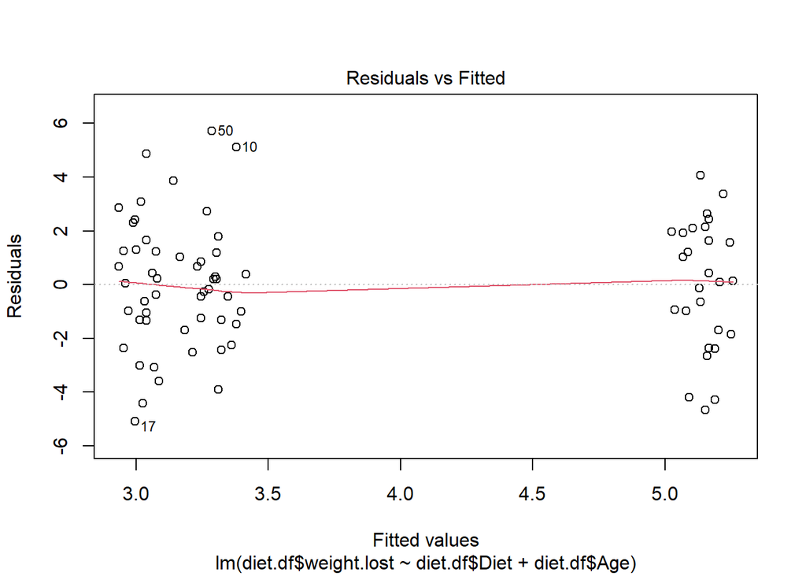

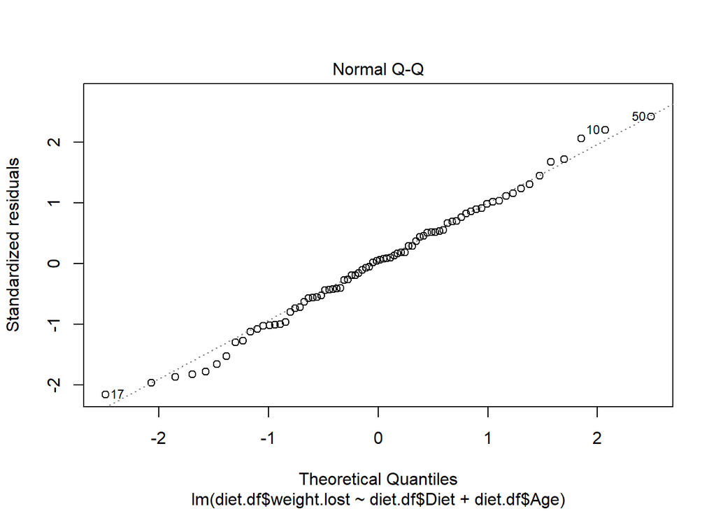

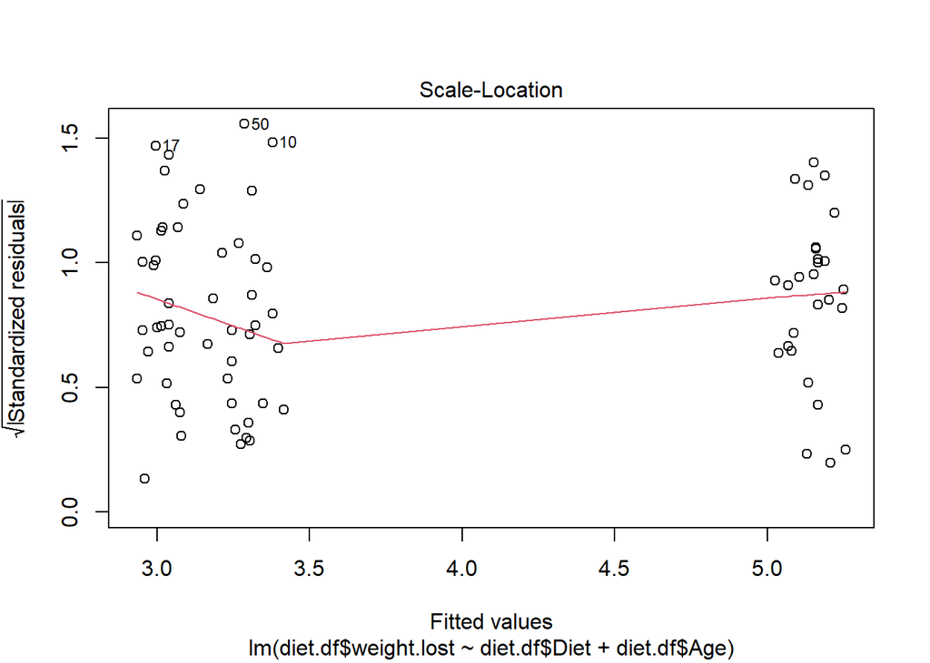

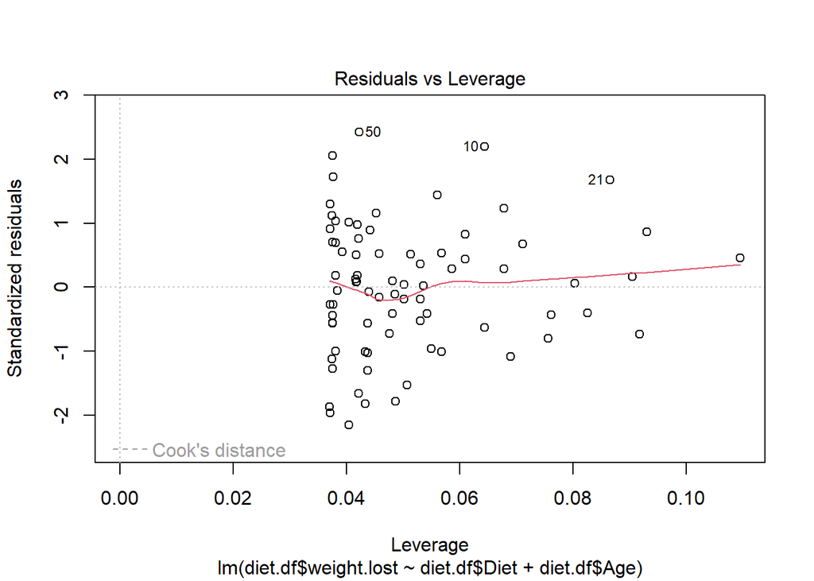

```r
plot(model2)
```

The plots for the residuals vs fitted and the QQ plot do not raise any concerns.

### Perhaps the weight before the diet is a better predictor?

Lets see, as the pre.weight is a numerical attribute. We are again using an ANCOVA model but with three explanatory variables this time.

```r
model3<-lm(diet.df$weight.lost~diet.df$Diet+ diet.df$gender + diet.df$pre.weight)
summary(model3)
```

```
##
## Call:
## lm(formula = diet.df$weight.lost ~ diet.df$Diet + diet.df$gender +
##     diet.df$pre.weight)
##
## Residuals:
##     Min      1Q  Median      3Q     Max
## -4.9842 -1.3278 -0.1511  1.5109  5.6365
##
## Coefficients:
##                    Estimate Std. Error t value Pr(>|t|)
## (Intercept)        -0.04217    3.70905  -0.011  0.99096
## diet.df$Diet2       0.10553    0.70059   0.151  0.88069
## diet.df$Diet3       1.82492    0.67110   2.719  0.00822 **
## diet.df$gender1    -0.48514    0.84959  -0.571  0.56978
## diet.df$pre.weight  0.04864    0.05404   0.900  0.37117
## ---
## Signif. codes:  0 '***' 0.001 '**' 0.01 '*' 0.05 '.' 0.1 ' ' 1
##
## Residual standard error: 2.39 on 71 degrees of freedom
##   (2 observations deleted due to missingness)
## Multiple R-squared:  0.1387, Adjusted R-squared:  0.09019
## F-statistic: 2.859 on 4 and 71 DF,  p-value: 0.02954
```

This model (model3) is no better than our previous one. Low $r^2$ and not many estimates are significant. The only one seems to be the different between diet 3 and the rest.

# What to look out for in an ANCOVA output?

An ANCOVA model is similar to a linear regression model

- In the summary(lm()) look at the $r^2$ which should be as close as 1 as possible, look at the F statistic which should be significant and finally look at the estimates for the coefficients and see which ones are significant.
- In the plot(lm()) look for equal variances in the residuals vs fitted plot (first plot) and for the residuals to be along the straight line in the qqplot (the second plot). ***

# Joining categories

Looking at weight loss we saw that the difference seemed to be more marked between Diet 3 and the other two. So lets join diet 1 and 2 together then model this instead. In order to do so we create a new variable diet.ind - see the code below:

```r
diet.df$diet.ind<-ifelse(diet.df$Diet=="3", "3", "1 or 2")
table(diet.df$diet.ind)
```

```
##
## 1 or 2      3
##     51     27
```

```r
model3<-aov(diet.df$weight.lost~diet.df$diet.ind)
summary.lm(model3)
```

```
##
## Call:
## aov(formula = diet.df$weight.lost ~ diet.df$diet.ind)
##
## Residuals:
##     Min      1Q  Median      3Q     Max
## -5.2549 -1.4549  0.1485  1.6252  5.8451
##
## Coefficients:
##                   Estimate Std. Error t value Pr(>|t|)
## (Intercept)         3.1549     0.3335   9.460 1.77e-14 ***
## diet.df$diet.ind3   1.9932     0.5669   3.516 0.000742 ***
## ---
## Signif. codes:  0 '***' 0.001 '**' 0.01 '*' 0.05 '.' 0.1 ' ' 1
##
## Residual standard error: 2.382 on 76 degrees of freedom
## Multiple R-squared:  0.1399, Adjusted R-squared:  0.1286
## F-statistic: 12.36 on 1 and 76 DF,  p-value: 0.0007418
```

This last model (model3) is not much of an improvement on the previous ones. (Look at $r^2$.)

At this point there are many other ways of proceeding with the analysis. One possible option is to check whether there are significant differences in the starting weights of the people allocated to the three diets, or their ages.

If you chose to use the Gender as an explanatory variable, then you may want to exclude the rows of data that have NA. It is unlikely that we will be able to “guess” or impute the missing values for gender in a meaningful way.

### Removing Missing values

We can try to see if gender is a better explainer of weight loss, but before we do we should remove the missing values for gender, this means we will have a smaller data set to use.

```r
diet2.df<-subset(diet.df, !is.na(diet.df$gender))
```

We now removed the two rows with missing values for gender.

```r
model.gender.aov<-aov(diet2.df$weight.lost~diet2.df$gender)
summary.lm(model.gender.aov)
```

```
##
## Call:
## aov(formula = diet2.df$weight.lost ~ diet2.df$gender)
##
## Residuals:
##     Min      1Q  Median      3Q     Max
## -5.9930 -1.6846 -0.2041  1.7264  5.1848
##
## Coefficients:
##                  Estimate Std. Error t value Pr(>|t|)
## (Intercept)        3.8930     0.3846  10.123  1.3e-15 ***
## diet2.df$gender1   0.1221     0.5836   0.209    0.835
## ---
## Signif. codes:  0 '***' 0.001 '**' 0.01 '*' 0.05 '.' 0.1 ' ' 1
##
## Residual standard error: 2.522 on 74 degrees of freedom
## Multiple R-squared:  0.0005914,  Adjusted R-squared:  -0.01291
## F-statistic: 0.04379 on 1 and 74 DF,  p-value: 0.8348
```

Clearly this has not helped at all as from this data Gender plays no part in explaining the differences in weight lost. Clue - Look at what happened to $r^2$

Overall the best model remains the one that uses either only the diet type, which was the first one we used.